# How to simulate survival data with the `sim.survdata` function

Jonathan Kropko and Jeffrey J. Harden

2020-01-10

# 1 Introduction

Simulating data with known properties is an essential step in the development of new statistical methods. Simulating survival data, however, is more challenging than most simulation tasks. To describe this difficulty and our approach to overcoming it, we quote from Harden and Kropko (2018):

> Typical methods for generating . . . durations often employ known distributions - such as the exponential, Weibull, or Gompertz — that imply specific shapes for the baseline hazard function. This approach is potentially problematic because it contradicts a key advantage of the Cox model — the ability to leave the distribution of the baseline hazard unspecified. By restricting the simulated data to a known (usually parametric) form, these studies impose an assumption that is not required in applications of the Cox model. In applied research, the baseline hazard in data can exhibit considerable heterogeneity, both across the many fields which employ the Cox model and within a given field . . . . Thus, simulating durations from one specific parametric distribution may not adequately approximate the data that many applied researchers analyze, reducing the simulation’s generalizability.

> Here we address these problems by introducing a novel method for simulating durations without specifying a particular distribution for the baseline hazard function. Instead, the method generates — at each iteration of the simulation — a unique baseline hazard by fitting a cubic spline to randomly-drawn points. This produces a wide variety of shapes for the baseline hazard, including those that are unimodal, multimodal, monotonically increasing or decreasing, and other shapes. The method then generates a density function based on each baseline hazard and draws durations accordingly. Because the shape of the baseline hazard can vary considerably, this approach matches the Cox model’s inherent flexibility. By remaining agnostic about the distribution of the baseline hazard, our method better constructs the assumed data generating process (DGP) of the Cox model. Moreover, repeating this process over many iterations in a simulation yields more heterogeneity in the simulated samples of data, which matches the fact that applied researchers analyze a wide variety of data with the Cox model. This increases the generalizability of the simulation results.

In this vignette we demonstrate the uses of the `sim.survdata()` function for generating survival data. To begin, we load the `coxed` library:

```r
library(coxed)
```

# 2 Simulating survival data using the flexible-hazard method

The flexible-hazard method described by Harden and Kropko (2018) first generates a baseline failure CDF: it plots points at (0, 0) and (`T`+1, 1), and it plots `knots` additional points with x-coordinates drawn uniformly from integers in [2, `T`] and y-coordinates drawn from U[0, 1]. It sorts these coordinates in ascending order (because a CDF must be non-decreasing) and if `spline=TRUE` it fits a spline using Hyman’s (1983) cubic smoothing function to preserve the CDF’s monotonicity. Next it constructs the failure-time PDF by computing the first differences of the CDF at each time point. It generates the survivor function by subtracting the failure CDF from 1. Finally, it computes the baseline hazard by dividing the failure PDF by the survivor function. Full technical details are listed in Harden and Kropko (2018).

## 2.1 Simulating a single dataset

To generate a survival dataset, use the `sim.survdata()` function, with the `num.data.frames` argument set to 1. Here we generate a single survival dataset with 1000 observations, in which durations can fall on any integer between 1 and 100:

```r
simdata <- sim.survdata(N=1000, T=100, num.data.frames=1)
```

## 2.2 Attributes of a simulation

The simulated data has several important attributes:

```r
attributes(simdata)
```

```
## $names
## [1] "data"             "xdata"            "baseline"         "xb"
## [5] "exp.xb"           "betas"            "ind.survive"      "marg.effect"
## [9] "marg.effect.data"
##
## $class
## [1] "simSurvdata"
```

The full survival dataset, including the durations (`y`), the censoring variable (`failed`), and the covariates, is contained in the data frame object stored in the `data` attribute:

```r
head(simdata$data, 10)
```

```
##            X1          X2          X3  y failed
## 1   0.4703870 -0.62929507  0.86462910 25   TRUE
## 2  -1.2706623 -0.38121433 -0.44931312 84   TRUE
## 3  -0.1157365  0.38816621 -0.11325093 98   TRUE
## 4   0.1006704  0.74195685 -0.05487702 29   TRUE
## 5   0.6927484  0.32709812 -0.18229045 99   TRUE
## 6  -0.1852444 -0.19436745 -0.26751373 16   TRUE
## 7   0.5515416  0.25259956 -0.06759957 20   TRUE
## 8  -0.2023994 -0.03790691  0.18906857 21   TRUE
## 9  -0.1679231  0.47492492 -0.20524394 28   TRUE
## 10  0.5086741  0.02615030  0.18138759 16   TRUE
```

The `xdata` attribute only contains the covariates:

```r
head(simdata$xdata, 10)
```

```
##            X1          X2          X3
## 1   0.4703870 -0.62929507  0.86462910
## 2  -1.2706623 -0.38121433 -0.44931312
## 3  -0.1157365  0.38816621 -0.11325093
## 4   0.1006704  0.74195685 -0.05487702
## 5   0.6927484  0.32709812 -0.18229045
## 6  -0.1852444 -0.19436745 -0.26751373
## 7   0.5515416  0.25259956 -0.06759957
## 8  -0.2023994 -0.03790691  0.18906857
## 9  -0.1679231  0.47492492 -0.20524394
## 10  0.5086741  0.02615030  0.18138759
```

The `baseline` attribute contains the baseline functions – failure PDF, failure CDF, survivor, and hazard – generated by the flexible-hazard method:

```r
head(simdata$baseline, 10)
```

```
##    time  failure.PDF  failure.CDF  survivor       hazard
## 1     1 9.680407e-06 9.680407e-06 0.9999903 9.680407e-06
## 2     2 6.776285e-05 7.744326e-05 0.9999226 6.776351e-05
## 3     3 1.839277e-04 2.613710e-04 0.9997386 1.839420e-04
## 4     4 3.581751e-04 6.195461e-04 0.9993805 3.582687e-04
## 5     5 5.905049e-04 1.210051e-03 0.9987899 5.908709e-04
## 6     6 8.809171e-04 2.090968e-03 0.9979090 8.819843e-04
## 7     7 1.229412e-03 3.320380e-03 0.9966796 1.231988e-03
## 8     8 1.635989e-03 4.956369e-03 0.9950436 1.641439e-03
## 9     9 2.100648e-03 7.057017e-03 0.9929430 2.111112e-03
## 10   10 2.623390e-03 9.680407e-03 0.9903196 2.642035e-03
```

As we demonstrate below, we can use the `survsim.plot()` function to plot these baseline functions.

The `betas` attribute contains the coefficients used in the simulation to generate the durations:

```r
simdata$betas
```

```
##             [,1]
## [1,] -0.08226631
## [2,] -0.02866504
## [3,] -0.09773443
```

These coefficients are the “true” coefficients in a data generating process, and a survival model such as the Cox proportional hazards model produces estimates of these coefficients. In this case, the Cox model estimates the coefficients as follows:

```r
model <- coxph(Surv(y, failed) ~ X1 + X2 + X3, data=simdata$data)
model$coefficients
```

```
##         X1         X2         X3
## -0.1002145 -0.1766074 -0.1388951
```

The coefficients and the covariates together form values of the linear predictor, contained in the `xb` attribute, and exponentiated values of the linear predictor, contained in the `exp.xb` attribute:

```r
head(cbind(simdata$xb, simdata$exp.xb))
```

```
##              [,1]      [,2]
## [1,] -0.105162270 0.9001784
## [2,]  0.159373587 1.1727760
## [3,]  0.009462935 1.0095079
## [4,] -0.024186628 0.9761035
## [5,] -0.048550082 0.9526096
## [6,]  0.046956223 1.0480761
```

In the course of generating simulations, the flexible-hazard method requires expressing each individual observation’s survivor function. These functions are contained in the rows of the `ind.survive` attribute, a matrix with `N` rows and `T` columns. For example, here’s the survivor function for observation 1:

```r
simdata$ind.survive[1,]
```

```
##   [1] 1.00000000 0.99999129 0.99993029 0.99976472 0.99944228 0.99891067
##   [7] 0.99811756 0.99701057 0.99553728 0.99364518 0.99128168 0.98839405
##  [13] 0.98492940 0.98083465 0.97605651 0.97054139 0.96423539 0.95708421
##  [19] 0.94903315 0.94002696 0.93000981 0.91892522 0.90671588 0.89093065
##  [25] 0.87037633 0.84688862 0.82231913 0.79854147 0.77745336 0.75911780
##  [31] 0.74226423 0.72680591 0.71265476 0.69972144 0.68791537 0.67714486
##  [37] 0.66731718 0.65833868 0.65011483 0.64255035 0.63554926 0.62901501
##  [43] 0.62285045 0.61695800 0.61123959 0.60559676 0.59993061 0.59414186
##  [49] 0.58813076 0.58219600 0.57669310 0.57160713 0.56692304 0.56262563
##  [55] 0.55869957 0.55512942 0.55189962 0.54899452 0.54639834 0.54409526
##  [61] 0.54206934 0.54030457 0.53878491 0.53749423 0.53641635 0.53553506
##  [67] 0.53483411 0.53429721 0.53390807 0.53365035 0.53350771 0.53346380
##  [73] 0.53345585 0.53340016 0.53324902 0.53295466 0.53246934 0.53174525
##  [79] 0.53073452 0.52938919 0.52766121 0.52550235 0.52286417 0.50802669
##  [85] 0.47478973 0.43136879 0.38615530 0.34789704 0.32573469 0.31717856
##  [91] 0.31239869 0.30968226 0.30730209 0.30352348 0.29660063 0.28476097
##  [97] 0.26617385 0.19998743 0.10445772 0.03670183 0.00000000
```

The last two attributes, `marg.effect` and `marg.effect.data`, are discussed further below.

## 2.3 Simulating multiple datasets

In a simulation, researchers generally want to create many iterations of simulated data to draw inferences from the sampling variation that produces each dataset. To generate multiple datasets, set the `num.data.frames` argument to the desired number of iterations. For example, to create 2 datasets, type:

```r
simdata <- sim.survdata(N=1000, T=100, num.data.frames=2)
summary(simdata)
```

```
##      Length Class  Mode
## [1,] 9      -none- list
## [2,] 9      -none- list
```

The output is now a list of two objects, where each object contains another version of the attributes described above. For example, to the see the data for the second iteration, type

```r
head(simdata[[2]]$data, 10)
```

```
##             X1           X2          X3  y failed
## 1   0.33110779  0.479317381  0.64046458 90   TRUE
## 2  -0.25750569 -0.172270590  0.09993011 19   TRUE
## 3  -0.14845399  0.005013061  0.19014953 98   TRUE
## 4   0.82711374 -0.364075317 -0.98510548 18   TRUE
## 5  -0.78966614 -0.495078038  0.17571872 63   TRUE
## 6   0.53965006 -0.075914453  0.52556369 18   TRUE
## 7   0.02582394 -0.280232813  0.29950253 96   TRUE
## 8  -0.62014220 -0.515513417  0.68882806 99   TRUE
## 9   0.09428632  0.029204926  0.34465389 69   TRUE
## 10  0.23683775 -0.119607771 -0.19003708 58  FALSE
```

In the above example we created two datasets to reduce the time needed to compile this vignette, but for research applications this number can be set as large as a researcher wants, even to `num.data.frames=1000` for example.

## 2.4 Plotting the baseline functions and histograms

The flexible-hazard method is designed to avoid assuming a particular parametric form for the hazard function, but it still employs a hazard function. To see the baseline functions, including hazard, use the `survsim.plot()` function. The first argument is the output of the `sim.survdata()` function. Every simulation iteration produces different durations (and if `fixed.hazard=FALSE`, different hazard functions), so it is necessary to use the `df` argument specify which simulation iteration to use when plotting histograms and baseline functions. To see the baseline functions for the first simulation iteration, specify `type="baseline"` as follows:

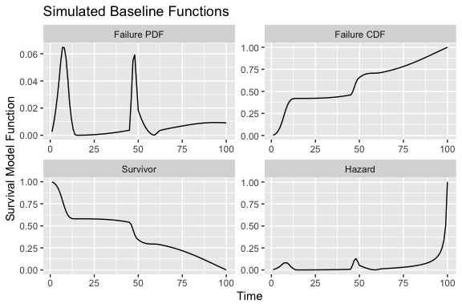

```r
survsim.plot(simdata, df=1, type="baseline")
```

To see the histograms of the simulated durations, linear predictors, and exponentiated linear predictors, specify `type="hist"`:

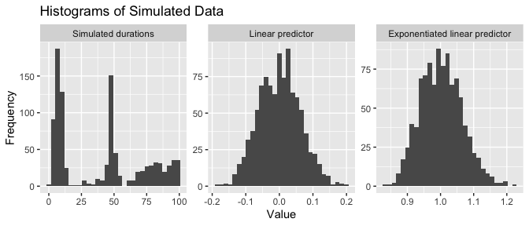

```r
survsim.plot(simdata, df=1, type="hist")
```

And to see both the baseline functions and the histograms, specify `type="both"`:

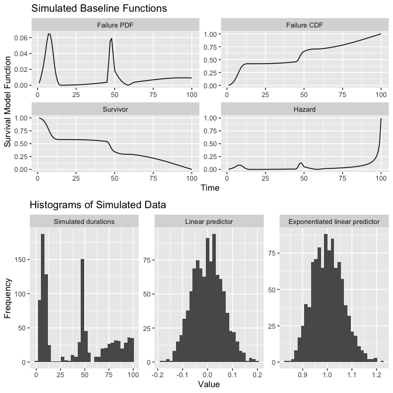

```r
survsim.plot(simdata, df=1, type="both")
```

The `survsim.plot()` function also has a `bins` argument, which allows the user to change the number of bins in these histograms (the default is 30).

# 3 Changing simulation parameters

The `sim.survdata()` function has a number of arguments that allow the user to change parameters of the simulation.

## 3.1 Changing the number of observations, time points, and covariates, and the censoring rate

The `N` argument changes the number of observations in each simulated dataset, the `T` argument changes the maximum possible survival time, `xvars` sets the number of covariates, and the `censor` argument specifies the proportion of observations that should be designated as right-censored. By default, `N=1000`, `T=100`, `xvars=3`, and `censor=.1`. To generate data with 700 observations, with durations ranging from 1 to 250, with 5 covariates and 20% of observations right-censored, type:

```r
simdata <- sim.survdata(N=700, T=250, xvars=5, censor=.2, num.data.frames = 1)
summary(simdata$data)
```

```
##        X1                 X2                 X3                  X4
##  Min.   :-1.73229   Min.   :-1.64167   Min.   :-1.623224   Min.   :-1.46203
##  1st Qu.:-0.32957   1st Qu.:-0.40637   1st Qu.:-0.332676   1st Qu.:-0.27878
##  Median :-0.01977   Median :-0.03392   Median : 0.003705   Median : 0.05492
##  Mean   :-0.01868   Mean   :-0.03925   Mean   :-0.016214   Mean   : 0.04324
##  3rd Qu.: 0.31159   3rd Qu.: 0.30386   3rd Qu.: 0.319065   3rd Qu.: 0.36611
##  Max.   : 1.41925   Max.   : 1.57249   Max.   : 1.381310   Max.   : 1.48289
##        X5                y            failed
##  Min.   :-1.4507   Min.   :  1.00   Mode :logical
##  1st Qu.:-0.3822   1st Qu.: 74.00   FALSE:143
##  Median :-0.0312   Median : 83.00   TRUE :557
##  Mean   :-0.0275   Mean   : 99.65
##  3rd Qu.: 0.2961   3rd Qu.:121.50
##  Max.   : 1.7137   Max.   :250.00
```

## 3.2 User-supplied coefficients

By default the coefficients are drawn from normal distributions, however the user may specify different coefficients with the `beta` argument if he or she wishes:

```r
simdata <- sim.survdata(N=1000, T=100, num.data.frames=1, beta=c(1, -1.5, 2))
simdata$betas
```

```
##      [,1]
## [1,]  1.0
## [2,] -1.5
## [3,]  2.0
```

Another way that a user can specify coefficients is to let these coefficients be dependent on time. An example of that is provided below.

## 3.3 User-supplied data

```r
summary(martinvanberg)
```

```
##     formdur           postel          prevdef            cont
##  Min.   :  1.00   Min.   :0.0000   Min.   :0.0000   Min.   :0.0000
##  1st Qu.:  6.00   1st Qu.:0.0000   1st Qu.:1.0000   1st Qu.:0.0000
##  Median : 19.00   Median :1.0000   Median :1.0000   Median :0.0000
##  Mean   : 28.03   Mean   :0.5764   Mean   :0.8522   Mean   :0.3251
##  3rd Qu.: 37.50   3rd Qu.:1.0000   3rd Qu.:1.0000   3rd Qu.:1.0000
##  Max.   :205.00   Max.   :1.0000   Max.   :1.0000   Max.   :1.0000
##      ident           rgovm            pgovno         tpgovno
##  Min.   :1.000   Min.   :0.0000   Min.   :1.000   Min.   : 0.000
##  1st Qu.:1.000   1st Qu.:0.0000   1st Qu.:1.000   1st Qu.: 2.080
##  Median :2.000   Median :0.4200   Median :2.000   Median : 5.890
##  Mean   :2.049   Mean   :0.8009   Mean   :2.261   Mean   : 6.552
##  3rd Qu.:3.000   3rd Qu.:1.4050   3rd Qu.:3.000   3rd Qu.: 8.600
##  Max.   :3.000   Max.   :3.2700   Max.   :6.000   Max.   :25.470
##     minority
##  Min.   :0.0000
##  1st Qu.:0.0000
##  Median :0.0000
##  Mean   :0.3596
##  3rd Qu.:1.0000
##  Max.   :1.0000
```

We will use the `postel`, `rgovm`, and `pgovno` variables to create a data frame that we pass to the `X` argument:

```r
mv.data <- dplyr::select(martinvanberg, postel, rgovm, pgovno)
simdata <- sim.survdata(T=100, X=mv.data, num.data.frames = 1)
```

The data now contain the exogenous covariates and the simulated duration and censoring variables:

```r
head(simdata$data)
```

```
##   postel rgovm pgovno  y failed
## 1      1  3.01      2 16  FALSE
## 2      1  1.95      2 14   TRUE
## 3      1  2.36      2 24   TRUE
## 4      0  2.36      2 26   TRUE
## 5      0  2.36      2 54   TRUE
## 6      1  1.46      2 57   TRUE
```

## 3.4 Simulated marginal effects

For example, suppose we are interested in comparing the **duration when X1 is 1** to the **duration when X1 is 0**. We specify `covariate=1` to indicate that `X1` is the variable whose values should be fixed to the ones specified with `low=0` and `high=1`. In this example we fix the coefficients so that `X1` has a large effect, to ensure that we see a larger marginal effect. To simulate with these parameters, we type:

```r
simdata <- sim.survdata(N=1000, T=100, num.data.frames=1, covariate=1, low=0, high=1,
                        beta = c(2, .1, .1))
```

The simulated marginal effect is

```r
simdata$marg.effect
```

```
## [1] -49
```

The covariates and durations for each of the low and high conditions are stored in `marg.effect.data`:

```r
head(simdata$marg.effect.data$low$x)
```

```
##   X1          X2         X3
## 1  0 -0.03092478 -0.6945487
## 2  0 -0.68202791  0.2176554
## 3  0  0.21257571 -0.5037913
## 4  0 -0.38117552 -0.2329270
## 5  0  0.43977773 -0.3927924
## 6  0 -0.28896466 -0.2706148
```

```r
head(simdata$marg.effect.data$low$y)
```

```
## [1] 29 25 99 17  7 65
```

```r
head(simdata$marg.effect.data$high$x)
```

```
##   X1          X2         X3
## 1  1 -0.03092478 -0.6945487
## 2  1 -0.68202791  0.2176554
## 3  1  0.21257571 -0.5037913
## 4  1 -0.38117552 -0.2329270
## 5  1  0.43977773 -0.3927924
## 6  1 -0.28896466 -0.2706148
```

```r
head(simdata$marg.effect.data$high$y)
```

```
## [1]  2  5 15 15  6 10
```

## 3.5 Fixed or varying hazard

A researcher might want to hold the hazard function fixed from one iteration to the next in order to isolate the effect of different factors. Alternatively, a researcher might want the hazard to vary from one iteration to the next in order to examine a range of possibilities within one analysis and to avoid making any restrictive assumptions about hazard. If `fixed.hazard=TRUE`, one baseline hazard is generated and the same function is used to generate all of the simulated datasets. If `fixed.hazard=FALSE` (the default), a new hazard function is generated with each simulation iteration. To illustrate, we create two simulated datasets, twice - once with `fixed.hazard=TRUE` and once with `fixed.hazard=FALSE`. If `fixed.hazard=TRUE`, both data frames yield the same baseline functions:

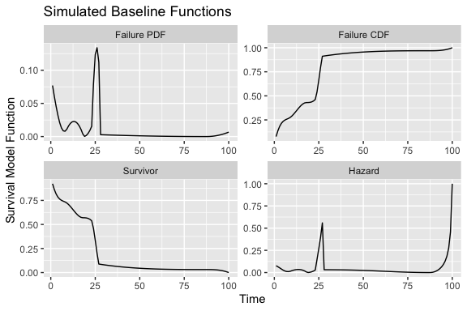

```r
simdata <- sim.survdata(N=1000, T=100, num.data.frames=2, fixed.hazard=TRUE)
survsim.plot(simdata, df=1, type="baseline")
```

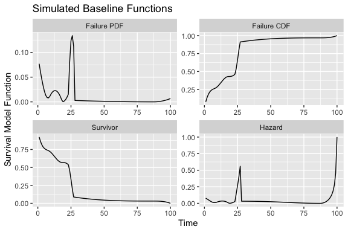

```r
survsim.plot(simdata, df=2, type="baseline")
```

If `fixed.hazard=FALSE`, the two data frames yield different baseline functions:

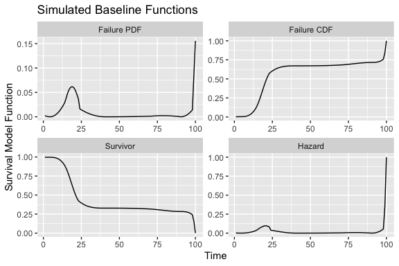

```r
simdata <- sim.survdata(N=1000, T=100, num.data.frames=2, fixed.hazard=FALSE)
survsim.plot(simdata, df=1, type="baseline")
```

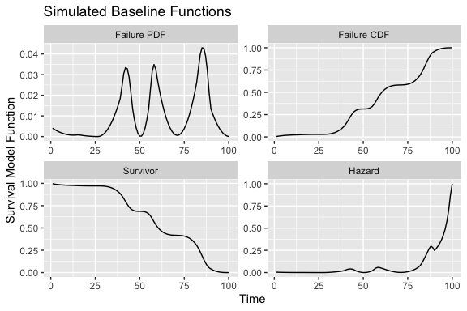

```r
survsim.plot(simdata, df=2, type="baseline")
```

## 3.6 Covariate-dependent censoring

An important assumption of many survival models is that the mechanism that causes some observations to be right-censored is independent from the covariates in the model. Some researchers, studying the effects of violations of the assumptions of a model, may want to dispel this assumption in the data generating process to see the effect on the model estimates. In the `sim.survdata()` function, if `censor.cond=FALSE` then a proportion of the observations specified by `censor` is randomly and uniformly selected to be right-censored. If `censor.cond=TRUE` then censoring depends on the covariates as follows: new coefficients are drawn from normal distributions with mean 0 and standard deviation of 0.1, and these new coefficients are used to create a new linear predictor using the `X` matrix. The observations with the largest `(100 x censor)` percent of the linear predictors are designated as right-censored. In other words, if `censor.cond=FALSE`, then a logit model in which the censoring indicator is regressed on the covariates should yield null results:

```r
simdata <- sim.survdata(N=1000, T=100, num.data.frames=1, censor.cond=FALSE)
logit <- glm(failed ~ X1 + X2 + X3, data=simdata$data, family=binomial(link="logit"))
summary(logit)
```

```
##
## Call:
## glm(formula = failed ~ X1 + X2 + X3, family = binomial(link = "logit"),
##     data = simdata$data)
##
## Deviance Residuals:
##     Min       1Q   Median       3Q      Max
## -2.3281   0.4079   0.4341   0.4565   0.5625
##
## Coefficients:
##             Estimate Std. Error z value Pr(>|z|)
## (Intercept)  2.30442    0.11093  20.774   <2e-16 ***
## X1          -0.09507    0.22355  -0.425    0.671
## X2          -0.28793    0.21613  -1.332    0.183
## X3           0.01774    0.22142   0.080    0.936
## ---
## Signif. codes:  0 '***' 0.001 '**' 0.01 '*' 0.05 '.' 0.1 ' ' 1
##
## (Dispersion parameter for binomial family taken to be 1)
##
##     Null deviance: 614.28  on 999  degrees of freedom
## Residual deviance: 612.26  on 996  degrees of freedom
## AIC: 620.26
##
## Number of Fisher Scoring iterations: 5
```

If, however, `censor.cond=TRUE`, then a logit model in which the censoring indicator is regressed on the covariates should yield significant results:

```r
simdata <- sim.survdata(N=1000, T=100, num.data.frames=1, censor.cond=TRUE)
logit <- glm(failed ~ X1 + X2 + X3, data=simdata$data, family=binomial(link="logit"))
summary(logit)
```

```
##
## Call:
## glm(formula = failed ~ X1 + X2 + X3, family = binomial(link = "logit"),
##     data = simdata$data)
##
## Deviance Residuals:
##     Min       1Q   Median       3Q      Max
## -3.0463   0.1962   0.3076   0.4725   1.5314
##
## Coefficients:
##             Estimate Std. Error z value Pr(>|z|)
## (Intercept)   2.6861     0.1503  17.875  < 2e-16 ***
## X1           -1.9463     0.2501  -7.783 7.10e-15 ***
## X2           -1.0272     0.2393  -4.292 1.77e-05 ***
## X3            1.0140     0.2354   4.308 1.65e-05 ***
## ---
## Signif. codes:  0 '***' 0.001 '**' 0.01 '*' 0.05 '.' 0.1 ' ' 1
##
## (Dispersion parameter for binomial family taken to be 1)
##
##     Null deviance: 650.17  on 999  degrees of freedom
## Residual deviance: 545.16  on 996  degrees of freedom
## AIC: 553.16
##
## Number of Fisher Scoring iterations: 6
```

## 3.7 User-specified hazard functions

For some applications, a researcher may want to specify his or her own hazard function rather than relying on the flexible-hazard method of generating hazard functions and drawing durations. The `sim.survdata()` allows a user to specify a customized hazard function with the `hazard.fun` argument, which takes a function with one argument that represents time. For example, suppose we want a lognormal hazard function with a mean of 50 and a standard deviation of 10. We can specify that function as follows:

```r
my.hazard <- function(t){
     dnorm((log(t) - log(50))/log(10)) /
          (log(10)*t*(1 - pnorm((log(t) - log(50))/log(10))))
     }
```

We can then pass that function to `sim.survdata()`. Note that the lognormal hazard function does not equal 0 when `T=100`. That means that many observations will be naturally right-censored above and beyond the amount of right-censoring we’ve specified with the `censor` argument (a proportion of .1 by default), simply because we haven’t allowed the simulated durations to extend to later time points. To reduce the number of additional right-censored observations, we increase `T` to 1000 to allow for the longer durations that the log-normal hazard function implies. Note, the `sim.survdata()` produces a warning with the number of additional right-censored observations:

```r
simdata <- sim.survdata(N=1000, T=1000, num.data.frames=1, hazard.fun = my.hazard)
```

```
## Warning in FUN(X[[i]], ...): 102 additional observations right-censored because the user-supplied hazard function
##                                   is nonzero at the latest timepoint. To avoid these extra censored observations, increase T
```

To see the hazard, we can use the `simsurv.plot()` function with `type="baseline"`:

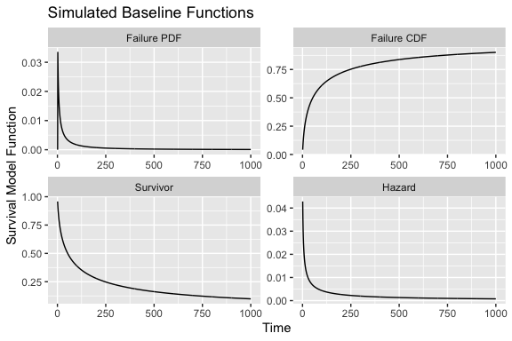

```r
survsim.plot(simdata, df=1, type="baseline")
```

## 3.8 Time-varying covariates

Time-varying covariates require a different data structure. The `Surv()` function in the `survival` package sets up the dependent variable for a Cox model. Generally it has two arguments: duration time and a censoring variable. But for time-varying covariates it replaces the duration argument with two time arguments, representing the start and end of discrete intervals, which allows a covariate to take on different values across different intervals for the same observation.

```r
simdata <- sim.survdata(N=1000, T=100, type="tvc", num.data.frames=1)
head(simdata$data, 20)
```

```
##    id failed start end          X1         X2        X3
## 1   1      0     0   1  0.01469904 0.05341122 -0.556977
## 2   1      0     1   2  1.36027774 0.05341122 -0.556977
## 3   1      0     2   3 -0.23918666 0.05341122 -0.556977
## 4   1      0     3   4  1.41099350 0.05341122 -0.556977
## 5   1      0     4   5 -0.95577116 0.05341122 -0.556977
## 6   1      0     5   6  0.12513168 0.05341122 -0.556977
## 7   1      0     6   7  1.80028128 0.05341122 -0.556977
## 8   1      0     7   8  0.54483915 0.05341122 -0.556977
## 9   1      0     8   9 -0.36908266 0.05341122 -0.556977
## 10  1      0     9  10 -1.76776208 0.05341122 -0.556977
## 11  1      0    10  11 -0.60065478 0.05341122 -0.556977
## 12  1      0    11  12  0.21421874 0.05341122 -0.556977
## 13  1      0    12  13 -2.05242445 0.05341122 -0.556977
## 14  1      0    13  14  1.02821532 0.05341122 -0.556977
## 15  1      0    14  15 -1.07863316 0.05341122 -0.556977
## 16  1      0    15  16 -0.30640921 0.05341122 -0.556977
## 17  1      0    16  17 -0.23648937 0.05341122 -0.556977
## 18  1      0    17  18  0.42593791 0.05341122 -0.556977
## 19  1      0    18  19  0.25492348 0.05341122 -0.556977
## 20  1      0    19  20 -1.81756530 0.05341122 -0.556977
```

## 3.9 Time-varying coefficients

The Cox model assumes proportional hazards, and one way to dispel this assumption is to allow the coefficients to vary over time. The `sim.survdata()` function generates data using time-varying coefficients if the `type="tvbeta"` argument is specified. If this option is specified, the first coefficient, whether coefficients are user-supplied or randomly generated, is interacted with the natural log of the time counter from 1 to `T` (the maximum possible duration). Durations are generated via proportional hazards, and coefficients are saved as a matrix to illustrate their dependence on time. To generate data with time-varying coefficients, type:

```r
simdata <- sim.survdata(N=1000, T=100, type="tvbeta", num.data.frames = 1)
```

The coefficients are saved as a matrix with a column to represent time:

```r
head(simdata$betas, 10)
```

```
##    time      beta1      beta2     beta3
## 1     1 0.00000000 0.02906644 0.1305112
## 2     2 0.01836634 0.02906644 0.1305112
## 3     3 0.02910995 0.02906644 0.1305112
## 4     4 0.03673267 0.02906644 0.1305112
## 5     5 0.04264531 0.02906644 0.1305112
## 6     6 0.04747629 0.02906644 0.1305112
## 7     7 0.05156082 0.02906644 0.1305112
## 8     8 0.05509901 0.02906644 0.1305112
## 9     9 0.05821990 0.02906644 0.1305112
## 10   10 0.06101164 0.02906644 0.1305112
```

An alternative approach to specifying time-varying coefficients is for the user to supply the matrix of time-varying coefficients. With this approach the coefficient matrix must have the same number of rows as the maximum duration specified with `T`, which in this case is 100. Suppose that we specify three coefficients for three covariates, over the time frame from 1 to 100. We want the first coefficient to be given by
$$\beta_{1_t} = \frac{(t - 25)^2}{2500},$$
and the second and third coefficients to be given by .5 and -.25 respectively:

```r
beta.mat <- data.frame(beta1 = (1:100 - 25)^2/2500,
                       beta2 = .5,
                       beta3 = -.25)
head(beta.mat)
```

```
##    beta1 beta2 beta3
## 1 0.2304   0.5 -0.25
## 2 0.2116   0.5 -0.25
## 3 0.1936   0.5 -0.25
## 4 0.1764   0.5 -0.25
## 5 0.1600   0.5 -0.25
## 6 0.1444   0.5 -0.25
```

We pass this matrix to the `sim.survdata()` function through the `beta` argument:

```r
simdata <- sim.survdata(N=1000, T=100, type="tvbeta", beta=beta.mat, num.data.frames = 1)
```

The data from this simulation are as follows:

```r
head(simdata$data, 10)
```

```
##             X1          X2          X3  y failed
## 1  -1.04794889 -0.20828491  0.01675329 49   TRUE
## 2  -0.01431394  0.51886871 -0.22659304  1   TRUE
## 3  -0.30846078  0.54423460 -0.83669997  2   TRUE
## 4   0.37710188 -0.09637786 -0.31775133 88   TRUE
## 5   0.04178889  0.85492612  0.92953035  5   TRUE
## 6  -0.28132522  0.29231458 -0.67048709 36   TRUE
## 7  -0.43522169 -0.05752147 -0.79727958 38   TRUE
## 8  -0.07002374  0.51574175 -0.14797325 39   TRUE
## 9   0.13781626  0.25550823  0.04055821  5   TRUE
## 10  0.47928755 -0.01261773 -0.14178916  3   TRUE
```

And the coefficients are as we specified earlier:

```r
head(simdata$betas, 10)
```

```
##    time  beta1 beta2 beta3
## 1     1 0.2304   0.5 -0.25
## 2     2 0.2116   0.5 -0.25
## 3     3 0.1936   0.5 -0.25
## 4     4 0.1764   0.5 -0.25
## 5     5 0.1600   0.5 -0.25
## 6     6 0.1444   0.5 -0.25
## 7     7 0.1296   0.5 -0.25
## 8     8 0.1156   0.5 -0.25
## 9     9 0.1024   0.5 -0.25
## 10   10 0.0900   0.5 -0.25
```

# 4 References

- Harden, J. J. and Kropko, J. (2018). “Simulating Duration Data for the Cox Model.”" *Political Science Research and Methods* https://doi.org/10.1017/psrm.2018.19
- Hyman, J. M. (1983) “Accurate Monotonicity Preserving Cubic Interpolation.” *SIAM J. Sci. Stat. Comput.* **4**, 645–654. https://doi.org/10.1137/0904045
- Martin, L. W and Vanberg, G. (2003) “Wasting Time? The Impact of Ideology and Size on Delay in Coalition Formation.” *British Journal of Political Science* **33** 323-344 https://doi.org/10.1017/S0007123403000140
- Sylvestre M.-P., Abrahamowicz M. (2008) :“Comparison of Algorithms to Generate Event Times Conditional on Time-Dependent Covariates.” *Statistics in Medicine* **27(14)**:2618–34. https://doi.org/10.1002/sim.3092